# Caso Pŕactico Final

Tomaremos el dataset de aprobación de crédito bancario en https://archive.ics.uci.edu/ml/datasets/Credit+Approval . Los datos también se pueden cargar de la carpeta de contenido en `crx.data`. La información del dataset está en https://archive.ics.uci.edu/ml/machine-learning-databases/credit-screening/crx.names y expone lo siguiente:

```
  1. Title: Credit Approval

  2. Sources:
      (confidential)
      Submitted by quinlan@cs.su.oz.au

  3.  Past Usage:

      See Quinlan,
      * "Simplifying decision trees", Int J Man-Machine Studies 27,
        Dec 1987, pp. 221-234.
      * "C4.5: Programs for Machine Learning", Morgan Kaufmann, Oct 1992

  4.  Relevant Information:

      This file concerns credit card applications.  All attribute names
      and values have been changed to meaningless symbols to protect
      confidentiality of the data.

      This dataset is interesting because there is a good mix of
      attributes -- continuous, nominal with small numbers of
      values, and nominal with larger numbers of values.  There
      are also a few missing values.

  5.  Number of Instances: 690

  6.  Number of Attributes: 15 + class attribute

  7.  Attribute Information:

      A1:   b, a.
      A2:   continuous.
      A3:   continuous.
      A4:   u, y, l, t.
      A5:   g, p, gg.
      A6:   c, d, cc, i, j, k, m, r, q, w, x, e, aa, ff.
      A7:   v, h, bb, j, n, z, dd, ff, o.
      A8:   continuous.
      A9:   t, f.
      A10:  t, f.
```

[output cut: 8 more lines]

```
      37 cases (5%) have one or more missing values.  The missing
      values from particular attributes are:

      A1:  12
      A2:  12
      A4:   6
      A5:   6
      A6:   9
      A7:   9
      A14: 13

  9.  Class Distribution

      +: 307 (44.5%)
      -: 383 (55.5%)
```

## Actividades a realizar

1. Carga los datos. Realiza una inspección por variables de la distribución de aprobación de crédito en función de cada atributo visualmente. Realiza las observaciones pertinentes. ¿ Qué variables son mejores para separar los datos?

```r
library(ggplot2)
cred <- read.csv("CASO_FINAL_crx.data", header = FALSE, na.strings = "?")
str(cred)
```

```
'data.frame':   690 obs. of  16 variables:
 $ V1 : Factor w/ 2 levels "a","b": 2 1 1 2 2 2 2 1 2 2 ...
 $ V2 : num  30.8 58.7 24.5 27.8 20.2 ...
 $ V3 : num  0 4.46 0.5 1.54 5.62 ...
 $ V4 : Factor w/ 3 levels "l","u","y": 2 2 2 2 2 2 2 2 3 3 ...
 $ V5 : Factor w/ 3 levels "g","gg","p": 1 1 1 1 1 1 1 1 3 3 ...
 $ V6 : Factor w/ 14 levels "aa","c","cc",..: 13 11 11 13 13 10 12 3 9 13 ...
 $ V7 : Factor w/ 9 levels "bb","dd","ff",..: 8 4 4 8 8 8 4 8 4 8 ...
 $ V8 : num  1.25 3.04 1.5 3.75 1.71 ...
 $ V9 : Factor w/ 2 levels "f","t": 2 2 2 2 2 2 2 2 2 2 ...
 $ V10: Factor w/ 2 levels "f","t": 2 2 1 2 1 1 1 1 1 1 ...
 $ V11: int  1 6 0 5 0 0 0 0 0 0 ...
 $ V12: Factor w/ 2 levels "f","t": 1 1 1 2 1 2 2 1 1 2 ...
 $ V13: Factor w/ 3 levels "g","p","s": 1 1 1 1 3 1 1 1 1 1 ...
 $ V14: int  202 43 280 100 120 360 164 80 180 52 ...
 $ V15: int  0 560 824 3 0 0 31285 1349 314 1442 ...
 $ V16: Factor w/ 2 levels "-","+": 2 2 2 2 2 2 2 2 2 2 ...
```

```r
histograma <- function(x) {
  min <- min(x, na.rm = TRUE)
  max <- max(x, na.rm = TRUE)
  media <- mean(x, na.rm = TRUE)
  mediana <- median(x, na.rm = TRUE)
  dt <- sd(x, na.rm = TRUE)

  hist(x, freq = F)
  lines(density(x, na.rm = TRUE),
        lwd = 2,
        col = "chocolate3")

  abline(v = media,
         col = "royalblue",
         lwd = 2)

  abline(v = mediana,
         col = "red",
         lwd = 2)

  legend(
    x = "topright",
    c("Density plot", "Mean", "Median"),
    col = c("chocolate3", "royalblue", "red"),
    lwd = c(2, 2, 2)
  )
}
```

```r
tbl = table(cred$V1, cred$V16)
tbl
```

```
      -   +
  a 112  98
  b 262 206
```

```r
chisq.test(tbl)
```

```
    Pearson's Chi-squared test with Yates' continuity correction

data:  tbl
X-squared = 0.31128, df = 1, p-value = 0.5769
```

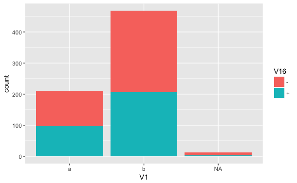

```r
ggplot(cred, aes(V1, fill=V16)) + geom_bar()
```

El resultado de este chi square parece muy bueno: p-value = 0.5769 En el gráfico de barras se ve una mayor frecuencia sobre la categoría b

```r
tbl = table(cred$V2, cred$V16)
tbl
```

[output not shown]

[output cut: 295 more lines]

[output not shown]

```r
chisq.test(tbl)
```

```
Chi-squared approximation may be incorrect
```

```
    Pearson's Chi-squared test

data:  tbl
X-squared = 375.88, df = 348, p-value = 0.1457
```

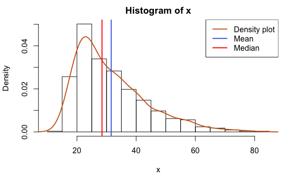

```r
histograma(cred$V2)
```

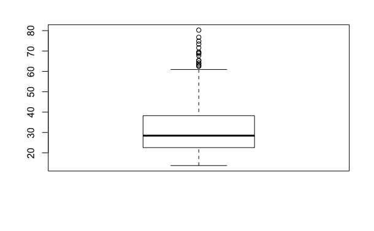

```r
boxplot(cred$V2)
```

```r
shapiro.test(cred$V2)
```

```
    Shapiro-Wilk normality test

data:  cred$V2
W = 0.90822, p-value < 2.2e-16
```

```r
tbl = table(cred$V3, cred$V16)
tbl
```

[output not shown]

[output cut: 161 more lines]

[output not shown]

```r
chisq.test(tbl)
```

```
Chi-squared approximation may be incorrect
```

```
    Pearson's Chi-squared test

data:  tbl
X-squared = 239.05, df = 214, p-value = 0.1154
```

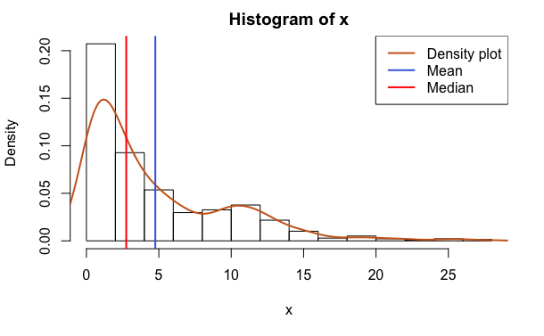

```r
histograma(cred$V3)
```

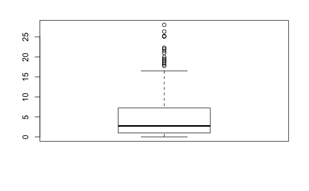

```r
boxplot(cred$V3)
```

```r
shapiro.test(cred$V3)
```

```
    Shapiro-Wilk normality test

data:  cred$V3
W = 0.83025, p-value < 2.2e-16
```

```r
tbl = table(cred$V4, cred$V16)
tbl
```

```
      -   +
  l   0   2
  u 263 256
  y 118  45
```

```r
chisq.test(tbl)
```

```
Chi-squared approximation may be incorrect
```

```
    Pearson's Chi-squared test

data:  tbl
X-squared = 26.234, df = 2, p-value = 2.011e-06
```

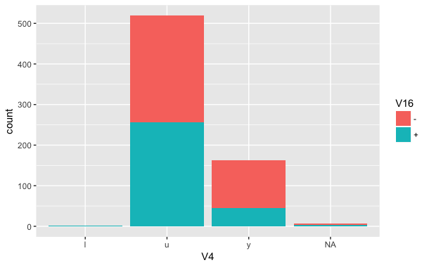

```r
ggplot(cred, aes(V4, fill=V16)) + geom_bar()
```

El resultado del test Chi para V4 es p-value = 2.011e-06 con lo que es un valor muy bajo. En el gráfico de barras se aprecia una mayor frecuencia para la categoría u de V4.

```r
tbl = table(cred$V5, cred$V16)
tbl
```

```
       -   +
  g  263 256
  gg   0   2
  p  118  45
```

```r
chisq.test(tbl)
```

```
Chi-squared approximation may be incorrect
```

```
    Pearson's Chi-squared test

data:  tbl
X-squared = 26.234, df = 2, p-value = 2.011e-06
```

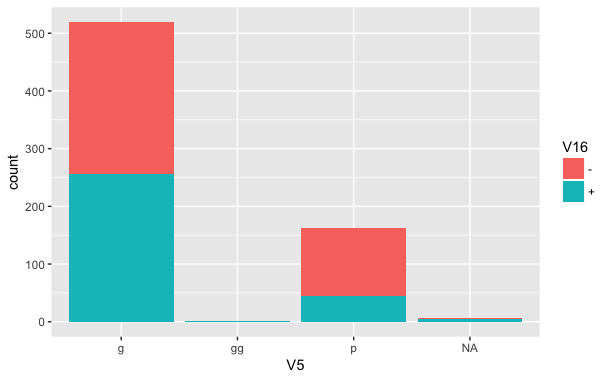

```r
ggplot(cred, aes(V5, fill=V16)) + geom_bar()
```

El test Chi square para V5 es también muy malo: p-value = 2.011e-06 En el gráfico de barras se aprecia una mayor frecuencia en la categoría g de V5.

```r
tbl = table(cred$V6, cred$V16)
tbl
```

```
      -  +
  aa 35 19
  c  75 62
  cc 12 29
  d  23  7
  e  11 14
  ff 46  7
  i  45 14
  j   7  3
  k  37 14
  m  22 16
  q  27 51
  r   1  2
  w  31 33
  x   6 32
```

```r
chisq.test(tbl)
```

```
Chi-squared approximation may be incorrect
```

```
    Pearson's Chi-squared test

data:  tbl
X-squared = 98.325, df = 13, p-value = 3.5e-15
```

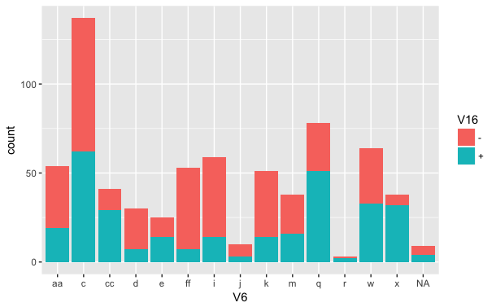

```r
ggplot(cred, aes(V6, fill=V16)) + geom_bar()
```

El test Chi para V6 nos da un p-valor muy bajo: 3.5e-15 warning incluido. En el gráfico de barras puede verse que para la categoría c de V6 hay mayor frecuencia de aprobaciones y denegaciones.

```r
tbl = table(cred$V7, cred$V16)
tbl
```

```
       -   +
  bb  34  25
  dd   4   2
  ff  49   8
  h   51  87
  j    5   3
  n    2   2
  o    1   1
  v  230 169
  z    2   6
```

```r
chisq.test(tbl)
```

```
Chi-squared approximation may be incorrect
```

```
    Pearson's Chi-squared test

data:  tbl
X-squared = 45.034, df = 8, p-value = 3.625e-07
```

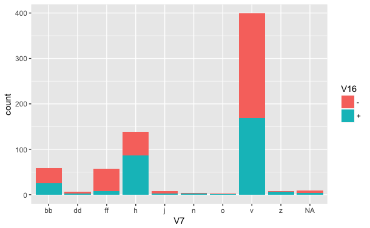

```r
ggplot(cred, aes(V7, fill=V16)) + geom_bar()
```

El p-valor para V7 en chi square es muy bajo también: 3.625e-07 En el gráfico de barras se puede apreciar una mayor frecuencia de aprobaciones y denegaciones para la categoría v de V7

```r
tbl = table(cred$V8, cred$V16)
tbl
```

[output not shown]

[output cut: 78 more lines]

[output not shown]

```r
chisq.test(tbl)
```

```
Chi-squared approximation may be incorrect
```

```
    Pearson's Chi-squared test

data:  tbl
X-squared = 214.15, df = 131, p-value = 6.17e-06
```

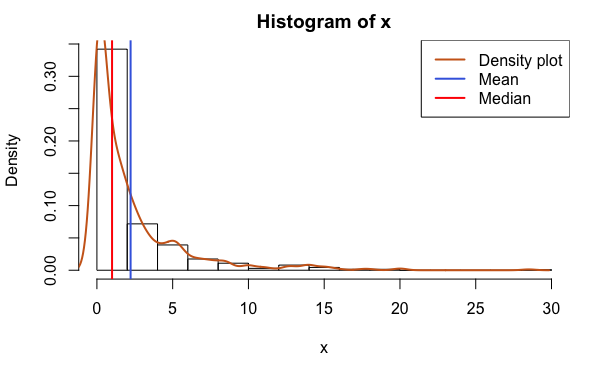

```r
histograma(cred$V8)
```

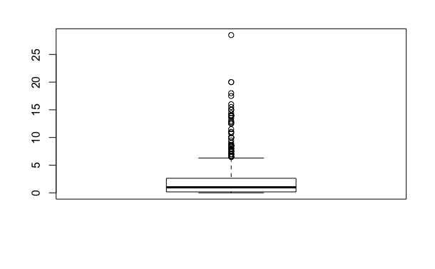

```r
boxplot(cred$V8)
```

```r
shapiro.test(cred$V8)
```

```
    Shapiro-Wilk normality test

data:  cred$V8
W = 0.66529, p-value < 2.2e-16
```

```r
tbl = table(cred$V9, cred$V16)
tbl
```

```
      -   +
  f 306  23
  t  77 284
```

```r
chisq.test(tbl)
```

```
    Pearson's Chi-squared test with Yates' continuity correction

data:  tbl
X-squared = 355.2, df = 1, p-value < 2.2e-16
```

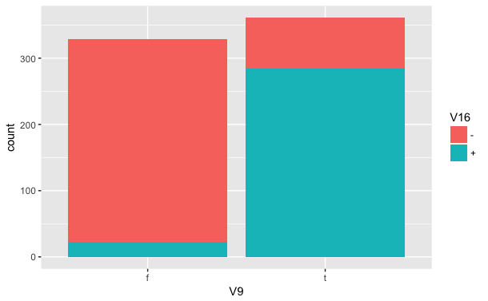

```r
ggplot(cred, aes(V9, fill=V16)) + geom_bar()
```

Para V9 el chi square es muy malo: p-value < 2.2e-16 El gráfico de barras muestra una mayor frecuencia de denegaciones en la categoría f y una mayor frecuencia de aprobaciones para la categoría t de V9.

```r
tbl = table(cred$V10, cred$V16)
tbl
```

```
      -   +
  f 297  98
  t  86 209
```

```r
chisq.test(tbl)
```

```
    Pearson's Chi-squared test with Yates' continuity correction

data:  tbl
X-squared = 143.07, df = 1, p-value < 2.2e-16
```

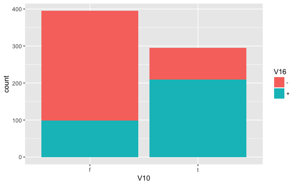

```r
ggplot(cred, aes(V10, fill=V16)) + geom_bar()
```

Para V10 el chi square es muy malo: p-value < 2.2e-16 En el gráfico de barras se observa una frecuencia mayor de denegaciones para la categoría f y una mayor frecuencia de aprobaciones para la categoría t.

```r
tbl = table(cred$V11, cred$V16)
tbl
```

```
       -   +
  0  297  98
  1   36  35
  2   26  19
  3    8  20
  4    3  12
  5    2  16
  6    3  20
  7    1  15
  8    0  10
  9    0  10
  10   4   4
  11   1  18
  12   1   7
  13   0   1
  14   0   8
  15   0   4
  16   0   3
  17   0   2
  19   0   1
  20   1   1
  23   0   1
  40   0   1
  67   0   1
```

```r
chisq.test(tbl)
```

```
Chi-squared approximation may be incorrect
```

```
    Pearson's Chi-squared test

data:  tbl
X-squared = 203.41, df = 22, p-value < 2.2e-16
```

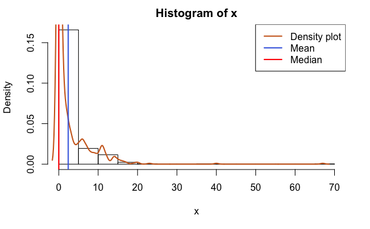

```r
histograma(cred$V11)
```

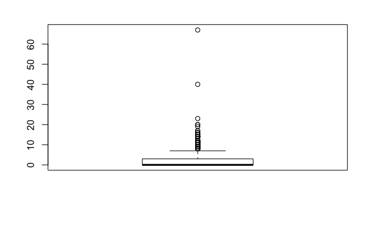

```r
boxplot(cred$V11)
```

```r
shapiro.test(cred$V11)
```

```
    Shapiro-Wilk normality test

data:  cred$V11
W = 0.53306, p-value < 2.2e-16
```

```r
tbl = table(cred$V12, cred$V16)
tbl
```

```
      -   +
  f 213 161
  t 170 146
```

```r
chisq.test(tbl)
```

```
    Pearson's Chi-squared test with Yates' continuity correction

data:  tbl
X-squared = 0.56827, df = 1, p-value = 0.4509
```

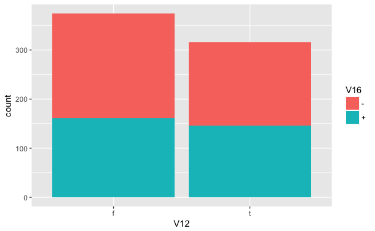

```r
ggplot(cred, aes(V12, fill=V16)) + geom_bar()
```

```r
tbl = table(cred$V13, cred$V16)
tbl
```

```
      -   +
  g 338 287
  p   3   5
  s  42  15
```

```r
chisq.test(tbl)
```

```
Chi-squared approximation may be incorrect
```

```
    Pearson's Chi-squared test

data:  tbl
X-squared = 9.1916, df = 2, p-value = 0.01009
```

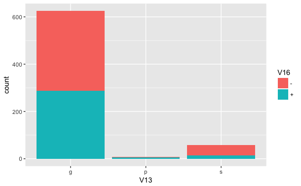

```r
ggplot(cred, aes(V13, fill=V16)) + geom_bar()
```

Para V13 el chi square no es muy bueno: p-value = 0.01009 El gráfico de barras muestra una mayor frecuencia de aprobaciones y denegaciones para la categoría g de V13.

```r
tbl = table(cred$V14, cred$V16)
tbl
```

```
        -  +
  0    51 81
  17    1  0
  20    1  1
  21    0  1
  22    0  1
  24    0  1
  28    1  0
  29    0  1
  30    0  1
  32    0  1
  40    1  3
  43    0  1
  45    1  0
  49    0  1
```

[output cut: 156 more lines]

```r
chisq.test(tbl)
```

```
Chi-squared approximation may be incorrect
```

```
    Pearson's Chi-squared test

data:  tbl
X-squared = 219.39, df = 169, p-value = 0.005489
```

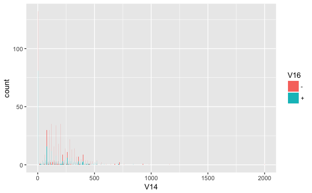

```r
ggplot(cred, aes(V14, fill=V16)) + geom_bar()
```

Para V14 el chi square no sale muy bien: p-value = 0.005489 El gráfico de barras muestra frecuencias similares de categorías de V14.

```r
tbl = table(cred$V15, cred$V16)
tbl
```

```
           -   +
  0      182 113
  1       27   2
  2        9   0
  3        5   1
  4        5   0
  5        8   0
  6        5   3
  7        2   2
  8        1   1
  9        1   0
  10       4   0
  11       1   1
  12       1   0
  13       2   0
```

[output cut: 226 more lines]

```r
chisq.test(tbl)
```

```
Chi-squared approximation may be incorrect
```

```
    Pearson's Chi-squared test

data:  tbl
X-squared = 314.94, df = 239, p-value = 0.0007081
```

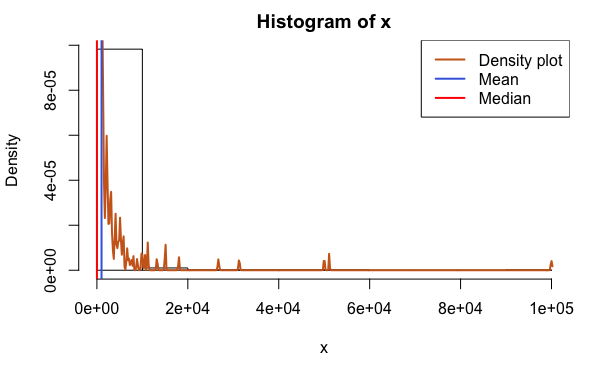

```r
histograma(cred$V15)
```

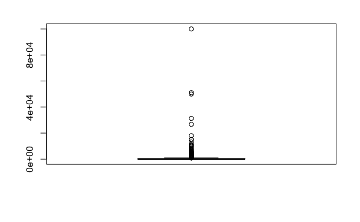

```r
boxplot(cred$V15)
```

```r
shapiro.test(cred$V15)
```

```
    Shapiro-Wilk normality test

data:  cred$V15
W = 0.16985, p-value < 2.2e-16
```

-No parece que ninguna variable siga una distribución normal a juzgar por los histogramas presentados.

2. Prepara el dataset convenientemente e imputa los valores faltantes usando la librería `missForest`

```r
library(missForest)
cred.imp <- missForest(cred, maxiter = 20,ntree = 500,variablewise = T)
```

```
  missForest iteration 1 in progress...done!
  missForest iteration 2 in progress...done!
  missForest iteration 3 in progress...done!
  missForest iteration 4 in progress...done!
```

```r
cred.imp$OOBerror
```

```
         PFC          MSE          MSE          PFC          PFC          PFC
2.846608e-01 9.710505e+01 0.000000e+00 2.923977e-03 2.923977e-03 7.312775e-01
         PFC          MSE          PFC          PFC          MSE          PFC
2.936858e-01 0.000000e+00 0.000000e+00 0.000000e+00 0.000000e+00 0.000000e+00
         PFC          MSE          MSE          PFC
0.000000e+00 2.767843e+04 0.000000e+00 0.000000e+00
```

```r
apply(cred,2,var,na.rm=TRUE)
```

[output not shown]

```
          V1           V2           V3           V4           V5           V6
          NA 1.429905e+02 2.478211e+01           NA           NA           NA
          V7           V8           V9          V10          V11          V12
          NA 1.119915e+01           NA           NA 2.364819e+01           NA
         V13          V14          V15          V16
          NA 3.020879e+04 2.714517e+07           NA
```

```r
apply(is.na(cred.imp$ximp),2,sum)
```

```
 V1  V2  V3  V4  V5  V6  V7  V8  V9 V10 V11 V12 V13 V14 V15 V16
  0   0   0   0   0   0   0   0   0   0   0   0   0   0   0   0
```

```r
cred <- cred.imp$ximp
str(cred)
```

```
'data.frame':   690 obs. of  16 variables:
 $ V1 : Factor w/ 2 levels "a","b": 2 1 1 2 2 2 2 1 2 2 ...
 $ V2 : num  30.8 58.7 24.5 27.8 20.2 ...
 $ V3 : num  0 4.46 0.5 1.54 5.62 ...
 $ V4 : Factor w/ 3 levels "l","u","y": 2 2 2 2 2 2 2 2 3 3 ...
 $ V5 : Factor w/ 3 levels "g","gg","p": 1 1 1 1 1 1 1 1 3 3 ...
 $ V6 : Factor w/ 14 levels "aa","c","cc",..: 13 11 11 13 13 10 12 3 9 13 ...
 $ V7 : Factor w/ 9 levels "bb","dd","ff",..: 8 4 4 8 8 8 4 8 4 8 ...
 $ V8 : num  1.25 3.04 1.5 3.75 1.71 ...
 $ V9 : Factor w/ 2 levels "f","t": 2 2 2 2 2 2 2 2 2 2 ...
 $ V10: Factor w/ 2 levels "f","t": 2 2 1 2 1 1 1 1 1 1 ...
 $ V11: num  1 6 0 5 0 0 0 0 0 0 ...
 $ V12: Factor w/ 2 levels "f","t": 1 1 1 2 1 2 2 1 1 2 ...
 $ V13: Factor w/ 3 levels "g","p","s": 1 1 1 1 3 1 1 1 1 1 ...
 $ V14: num  202 43 280 100 120 360 164 80 180 52 ...
 $ V15: num  0 560 824 3 0 ...
 $ V16: Factor w/ 2 levels "-","+": 2 2 2 2 2 2 2 2 2 2 ...
```

3. Divide el dataset tomando las primeras 590 instancias como train y las últimas 100 como test.

```r
cred$V16 <- as.numeric(cred$V16) - 1
X <- cred[,1:15]
dim(X)
```

```
[1] 690  15
```

```r
y <- cred$V16
unique(y)
```

```
[1] 1 0
```

```r
X_train <- X[1:590,]
y_train <- y[1:590]
X_test <- X[591:690,]
y_test <- y[591:690]
```

4. Entrena un modelo de regresión logística con regularización Ridge y Lasso en train seleccionando el que mejor **AUC** tenga. Da las métricas en test.

## Regresión logística con regularización Ridge

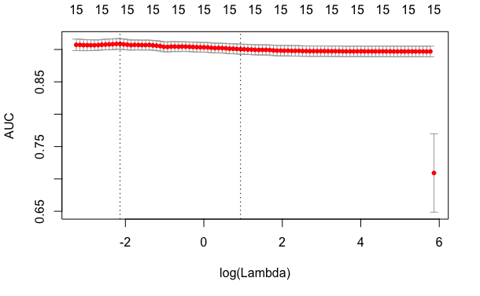

```r
X_train <- data.matrix(X_train)
X_test <- data.matrix(X_test)
library(glmnet)
set.seed(999)
cv.ridge <- cv.glmnet(X_train, y_train, family='binomial', alpha=0, parallel=TRUE, standardize=TRUE, type.measure='auc')
# Resultados
plot(cv.ridge)
```

```r
#este es el mejor valor de lambda
cv.ridge$lambda.min
```

```
[1] 0.1181697
```

```r
#este es el valor del error que se estima para ese valor lambda mínimo dado en MSE
max(cv.ridge$cvm)
```

```
[1] 0.9085512
```

Vemos los coeficientes

```r
coef(cv.ridge, s=cv.ridge$lambda.min)
```

```
16 x 1 sparse Matrix of class "dgCMatrix"
                        1
(Intercept) -3.371327e+00
V1          -4.033407e-02
V2           2.151454e-03
V3           1.441320e-02
V4          -2.702632e-01
V5          -8.707066e-02
V6           2.837543e-02
V7           8.655165e-03
V8           6.199125e-02
V9           1.702642e+00
V10          6.417367e-01
V11          5.636266e-02
V12         -8.824113e-03
V13         -8.706830e-02
V14         -5.942138e-04
V15          3.687251e-05
```

Damos métricas en el test

```r
y_pred <- as.numeric(predict.glmnet(cv.ridge$glmnet.fit, newx=X_test, s=cv.ridge$lambda.min)>.5)
library(caret)
library(ggplot2)
library(lattice)
library(e1071)
confusionMatrix(as.factor(y_test), as.factor(y_pred), mode="everything")
```

```
Confusion Matrix and Statistics

          Reference
Prediction  0  1
         0 86  0
         1  8  6

               Accuracy : 0.92
                 95% CI : (0.8484, 0.9648)
    No Information Rate : 0.94
    P-Value [Acc > NIR] : 0.85371

                  Kappa : 0.5633
 Mcnemar's Test P-Value : 0.01333

            Sensitivity : 0.9149
            Specificity : 1.0000
         Pos Pred Value : 1.0000
         Neg Pred Value : 0.4286
              Precision : 1.0000
                 Recall : 0.9149
                     F1 : 0.9556
             Prevalence : 0.9400
         Detection Rate : 0.8600
   Detection Prevalence : 0.8600
      Balanced Accuracy : 0.9574

       'Positive' Class : 0
```

## Regresión logística con regularización Lasso

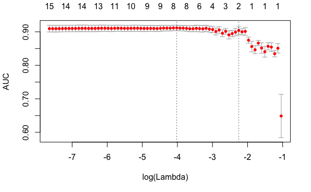

```r
library(glmnet)
set.seed(999)
cv.lasso <- cv.glmnet(X_train, y_train, family='binomial', alpha=1, parallel=TRUE, standardize=TRUE, type.measure='auc')
# Resultados
plot(cv.lasso)
```

```r
#este es el mejor valor de lambda
cv.lasso$lambda.min
```

```
[1] 0.01796074
```

```r
#este es el valor del error que se estima para ese valor lambda mínimo dado en MSE
max(cv.lasso$cvm)
```

```
[1] 0.9117109
```

Vemos los coeficientes

```r
coef(cv.lasso, s=cv.lasso$lambda.min)
```

```
16 x 1 sparse Matrix of class "dgCMatrix"
                        1
(Intercept) -5.510004e+00
V1           .
V2           .
V3           .
V4          -3.830015e-01
V5           .
V6           1.702579e-02
V7           .
V8           3.634871e-02
V9           3.027609e+00
V10          7.157389e-01
V11          6.218372e-02
V12          .
V13          .
V14         -4.290750e-04
V15          4.669441e-05
```

Damos métricas en el test

```r
y_pred <- as.numeric(predict.glmnet(cv.lasso$glmnet.fit, newx=X_test, s=cv.lasso$lambda.min)>.5)
library(caret)
library(ggplot2)
library(lattice)
library(e1071)
confusionMatrix(as.factor(y_test), as.factor(y_pred), mode="everything")
```

```
Confusion Matrix and Statistics

          Reference
Prediction  0  1
         0 85  1
         1  7  7

               Accuracy : 0.92
                 95% CI : (0.8484, 0.9648)
    No Information Rate : 0.92
    P-Value [Acc > NIR] : 0.5926

                  Kappa : 0.5951
 Mcnemar's Test P-Value : 0.0771

            Sensitivity : 0.9239
            Specificity : 0.8750
         Pos Pred Value : 0.9884
         Neg Pred Value : 0.5000
              Precision : 0.9884
                 Recall : 0.9239
                     F1 : 0.9551
             Prevalence : 0.9200
         Detection Rate : 0.8500
   Detection Prevalence : 0.8600
      Balanced Accuracy : 0.8995

       'Positive' Class : 0
```

Conclusiones: El recall de Lasso mejora

Seleccionaríamos el modelo Lasso por ser el mejor.

5. Aporta los *log odds* de las variables predictoras sobre la variable objetivo.

Buscamos el mejor modelo

```r
fit1 <- glm(V16~., data=cred, family=binomial)
```

```
glm.fit: fitted probabilities numerically 0 or 1 occurred
```

```r
fit0 <- glm(V16~1, data=cred, family=binomial)
library(MASS)
step <-stepAIC(fit0,direction="both",scope=list(upper=fit1,lower=fit0))
```

```
Start:  AIC=950.16
V16 ~ 1
```

```
glm.fit: fitted probabilities numerically 0 or 1 occurred
```

```
       Df Deviance    AIC
+ V9    1   540.95 544.95
+ V11   1   762.74 766.74
+ V10   1   798.66 802.66
+ V15   1   862.80 866.80
+ V8    1   863.32 867.32
+ V6   13   846.67 874.67
+ V7    8   902.50 920.50
+ V3    1   918.36 922.36
+ V5    2   919.84 925.84
+ V4    2   919.84 925.84
+ V2    1   929.91 933.91
+ V13   2   938.55 944.55
+ V14   1   940.70 944.70
<none>      948.16 950.16
+ V12   1   947.47 951.47
+ V1    1   947.76 951.76

Step:  AIC=544.95
V16 ~ V9
```

```
glm.fit: fitted probabilities numerically 0 or 1 occurred
```

```
       Df Deviance    AIC
+ V11   1   503.21 509.21
+ V15   1   505.09 511.09
+ V10   1   507.67 513.67
+ V4    2   518.66 526.66
+ V5    2   518.66 526.66
+ V13   2   521.04 529.04
+ V6   13   505.45 535.45
+ V8    1   532.97 538.97
+ V14   1   536.47 542.47
<none>      540.95 544.95
+ V12   1   539.26 545.26
+ V3    1   539.69 545.69
+ V7    8   526.58 546.58
+ V1    1   540.64 546.64
+ V2    1   540.68 546.68
- V9    1   948.16 950.16

Step:  AIC=509.21
V16 ~ V9 + V11
```

```
glm.fit: fitted probabilities numerically 0 or 1 occurred
```

```
       Df Deviance    AIC
+ V15   1   477.87 485.87
+ V13   2   484.00 494.00
+ V4    2   484.15 494.15
+ V5    2   484.15 494.15
+ V6   13   470.46 502.46
+ V10   1   498.33 506.33
+ V8    1   499.68 507.68
+ V7    8   486.96 508.96
<none>      503.21 509.21
+ V14   1   501.45 509.45
+ V12   1   501.99 509.99
+ V1    1   503.16 511.16
+ V2    1   503.17 511.17
+ V3    1   503.19 511.19
- V11   1   540.95 544.95
- V9    1   762.74 766.74
```

```
glm.fit: fitted probabilities numerically 0 or 1 occurred
```

```
Step:  AIC=485.87
V16 ~ V9 + V11 + V15
```

[output not shown]

```
       Df Deviance    AIC
+ V13   2   462.37 474.37
+ V5    2   464.59 476.59
+ V4    2   464.59 476.59
+ V6   13   446.26 480.26
+ V10   1   473.35 483.35
+ V8    1   473.93 483.93
+ V14   1   475.61 485.61
<none>      477.87 485.87
+ V12   1   476.52 486.52
+ V3    1   477.73 487.73
+ V1    1   477.82 487.82
+ V2    1   477.83 487.83
+ V7    8   463.88 487.88
- V15   1   503.21 509.21
- V11   1   505.09 511.09
- V9    1   723.20 729.20
```

```
glm.fit: fitted probabilities numerically 0 or 1 occurred
```

```
Step:  AIC=474.37
V16 ~ V9 + V11 + V15 + V13
```

[output not shown]

```
       Df Deviance    AIC
+ V4    2   449.66 465.66
+ V5    2   449.66 465.66
+ V6   13   429.42 467.42
+ V10   1   456.49 470.49
+ V8    1   457.91 471.91
+ V14   1   460.30 474.30
<none>      462.37 474.37
+ V7    8   447.35 475.35
+ V12   1   461.69 475.69
+ V2    1   462.15 476.15
+ V1    1   462.30 476.30
+ V3    1   462.36 476.36
- V13   2   477.87 485.87
- V15   1   484.00 494.00
- V11   1   489.51 499.51
- V9    1   719.88 729.88
```

```
glm.fit: fitted probabilities numerically 0 or 1 occurred
```

```
Step:  AIC=465.66
V16 ~ V9 + V11 + V15 + V13 + V4
```

[output not shown]

```
       Df Deviance    AIC
+ V6   13   419.24 461.24
+ V10   1   444.44 462.44
+ V7    8   431.71 463.71
+ V8    1   446.69 464.69
+ V14   1   446.94 464.94
<none>      449.66 465.66
+ V12   1   448.79 466.79
+ V2    1   449.26 467.26
+ V1    1   449.62 467.62
+ V3    1   449.63 467.63
- V4    2   462.37 474.37
- V13   2   464.59 476.59
- V15   1   469.64 483.64
- V11   1   474.35 488.35
- V9    1   707.84 721.84
```

```
glm.fit: fitted probabilities numerically 0 or 1 occurred
```

```
Step:  AIC=461.24
V16 ~ V9 + V11 + V15 + V13 + V4 + V6
```

[output not shown]

```
       Df Deviance    AIC
+ V14   1   411.43 455.43
+ V10   1   416.59 460.59
<none>      419.24 461.24
+ V8    1   417.82 461.82
+ V12   1   417.90 461.90
+ V1    1   419.14 463.14
+ V2    1   419.16 463.16
+ V3    1   419.18 463.18
+ V7    8   406.81 464.81
- V6   13   449.66 465.66
- V4    2   429.42 467.42
- V13   2   434.99 472.99
- V15   1   436.70 476.70
- V11   1   441.46 481.46
- V9    1   633.35 673.35
```

```
glm.fit: fitted probabilities numerically 0 or 1 occurred
```

```
Step:  AIC=455.43
V16 ~ V9 + V11 + V15 + V13 + V4 + V6 + V14
```

[output not shown]

```
       Df Deviance    AIC
+ V10   1   408.91 454.91
<none>      411.43 455.43
+ V8    1   410.13 456.13
+ V3    1   410.77 456.77
+ V12   1   410.82 456.82
+ V7    8   397.30 457.30
+ V2    1   411.36 457.36
+ V1    1   411.39 457.39
- V14   1   419.24 461.24
- V4    2   422.89 462.89
- V6   13   446.94 464.94
- V13   2   427.22 467.22
- V15   1   429.19 471.19
- V11   1   430.33 472.33
- V9    1   625.11 667.11
```

```
glm.fit: fitted probabilities numerically 0 or 1 occurred
```

```
Step:  AIC=454.91
V16 ~ V9 + V11 + V15 + V13 + V4 + V6 + V14 + V10
```

[output not shown]

```
       Df Deviance    AIC
<none>      408.91 454.91
+ V8    1   407.41 455.41
- V10   1   411.43 455.43
+ V3    1   408.39 456.39
+ V12   1   408.52 456.52
+ V7    8   394.61 456.61
+ V2    1   408.69 456.69
+ V1    1   408.89 456.89
- V11   1   414.10 458.10
- V14   1   416.59 460.59
- V4    2   419.58 461.58
- V6   13   441.61 461.61
- V13   2   425.39 467.39
- V15   1   425.46 469.46
- V9    1   618.06 662.06
```

```r
mod <- glm(V16 ~ V1 + V2 + V3 + V12, data=cred, family=binomial)
mod$coefficients
```

```
(Intercept)         V1b          V2          V3        V12t
-1.30660041 -0.10526615  0.02299225  0.07891018  0.12235391
```

```r
step$residuals
```

[output not shown]

[output cut: 175 more lines]

[output not shown]

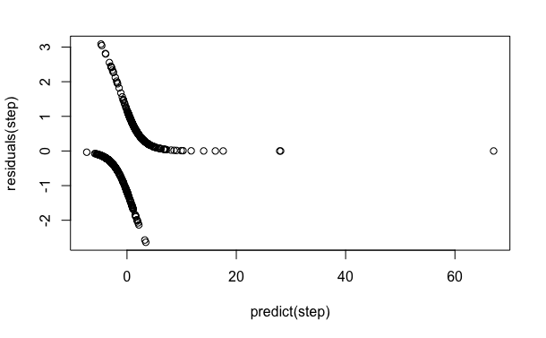

```r
plot(predict(step),residuals(step))
```

```r
coefficients(step)
```

```
  (Intercept)           V9t           V11           V15          V13p
 12.933154071   3.641480582   0.114843152   0.000525479   3.846077347
         V13s           V4u           V4y           V6c          V6cc
  0.164998009 -16.025081394 -16.839958107   0.435780516   1.617981285
          V6d           V6e          V6ff           V6i           V6j
  0.140654986   0.298569524  -1.217116931  -0.312393118   0.198286416
          V6k           V6m           V6q           V6r           V6w
 -0.115584980   0.268830607   0.653717362   0.988498314   0.910182074
          V6x           V14          V10t
  2.839227730  -0.002294025   0.578012530
```

```r
# predecimos 1 si la probabilidad es mayor que 0.5 y 0 si es menor que 0.5 y comparamos
y_pred <- predict(step)>.5
head(y_pred)
```

```
    1     2     3     4     5     6
 TRUE  TRUE  TRUE  TRUE  TRUE FALSE
```

```r
head(cred$V16)
```

```
[1] 1 1 1 1 1 1
```

La matriz de confusión y las métricas de error se pueden calcular. Para obtener todas las que se han dado incluir la opción `mode="everything"` . Además se obtiene intervalo de confianza para el accuracy

```r
y_pred <- as.numeric(predict(mod, subset(cred,select = -V16 ), type="response")>.5)
y <- as.numeric(cred$V16)
# install.packages(c("e1071", "caret", "e1071")
library(caret)
library(ggplot2)
library(lattice)
library(e1071)
confusionMatrix(as.factor(y), as.factor(y_pred), mode="everything")
```

```
Confusion Matrix and Statistics

          Reference
Prediction   0   1
         0 311  72
         1 197 110

               Accuracy : 0.6101
                 95% CI : (0.5726, 0.6467)
    No Information Rate : 0.7362
    P-Value [Acc > NIR] : 1

                  Kappa : 0.1775
 Mcnemar's Test P-Value : 4.018e-14

            Sensitivity : 0.6122
            Specificity : 0.6044
         Pos Pred Value : 0.8120
         Neg Pred Value : 0.3583
              Precision : 0.8120
                 Recall : 0.6122
                     F1 : 0.6981
             Prevalence : 0.7362
         Detection Rate : 0.4507
   Detection Prevalence : 0.5551
      Balanced Accuracy : 0.6083

       'Positive' Class : 0
```

Observamos cómo influyen las variables en V16 a través de los coeficientes y los *log odds*

```r
coef(mod)
```

```
(Intercept)         V1b          V2          V3        V12t
-1.30660041 -0.10526615  0.02299225  0.07891018  0.12235391
```

```r
exp(coef(mod))
```

```
(Intercept)         V1b          V2          V3        V12t
  0.2707389   0.9000849   1.0232586   1.0821071   1.1301540
```

Conclusiones:

Obtenemos un intervalo de confianza para los valores de los coeficientes:

```r
exp(confint(mod))
```

```
                2.5 %    97.5 %
(Intercept) 0.1583010 0.4563556
V1b         0.6441238 1.2588648
V2          1.0095014 1.0375214
V3          1.0470209 1.1196356
V12t        0.8278101 1.5432558
```

6. Si por cada verdadero positivo ganamos 100e y por cada falso positivo perdemos 20e. ¿ Qué rentabilidad aporta aplicar este modelo?